# Anomalías térmicas en el Parque Nacional Palo Verde

Detecciones del sensor MODIS (MODIS_SP de NASA FIRMS) y área quemada (MCD64A1)

Autor/a

Organización Incendios Forestales

Fecha de publicación

21 de octubre de 2026

## Introducción

Este reporte presenta las anomalías térmicas (detecciones de fuego activo) registradas por el sensor MODIS en el [Parque Nacional Palo Verde](https://www.sinac.go.cr/), Costa Rica. Los datos provienen del producto **MODIS_SP** (procesamiento estándar) del sistema [FIRMS](https://firms.modaps.eosdis.nasa.gov/) de la NASA, y el límite del parque del [WFS del SINAC](https://geos1pne.sirefor.go.cr/wfs).

El período analizado va del **04/01/2001** al **01/06/2026**, con un total de **266** detecciones dentro del parque. El límite del parque proviene de la capa oficial de áreas silvestres protegidas del SINAC (escala 1:5000, publicada en 2019): está delimitado con una precisión muy superior a la de los píxeles MODIS (~1 km), así que el recorte no introduce error apreciable por la geometría del límite.

## Mapa animado

Detecciones mensuales de anomalías térmicas; el color indica la potencia radiativa del fuego (FRP).

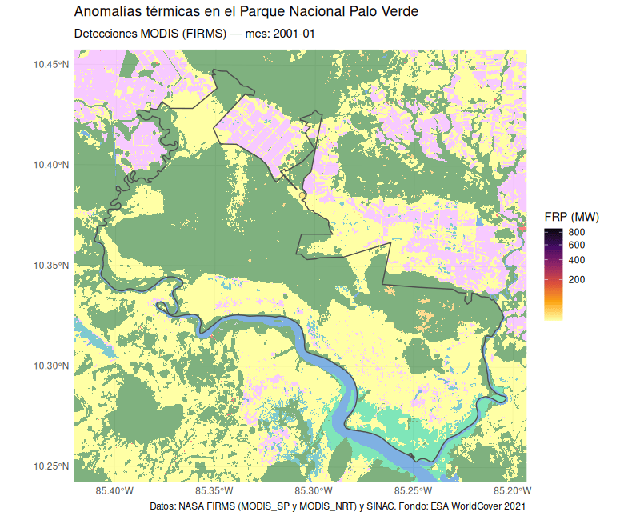

## Video resumen

Resumen mensual 2001–2026 en formato de video: detecciones de fuego activo (MODIS) con su estela de los meses recientes y píxeles de área quemada (MCD64A1), sobre el relieve del parque teñido por la cobertura de la tierra (WorldCover 2021). Los contadores muestran el acumulado desde 2001 y, debajo, el mes en curso con sus valores, cada serie por separado: son magnitudes complementarias y no sumables.

[video not shown]

El cartel estático resume las dos series mensuales del video: los acumulados arriba y, en paneles separados —son magnitudes complementarias y no sumables—, las hectáreas quemadas y las detecciones por mes, con el mes máximo de cada serie rotulado.

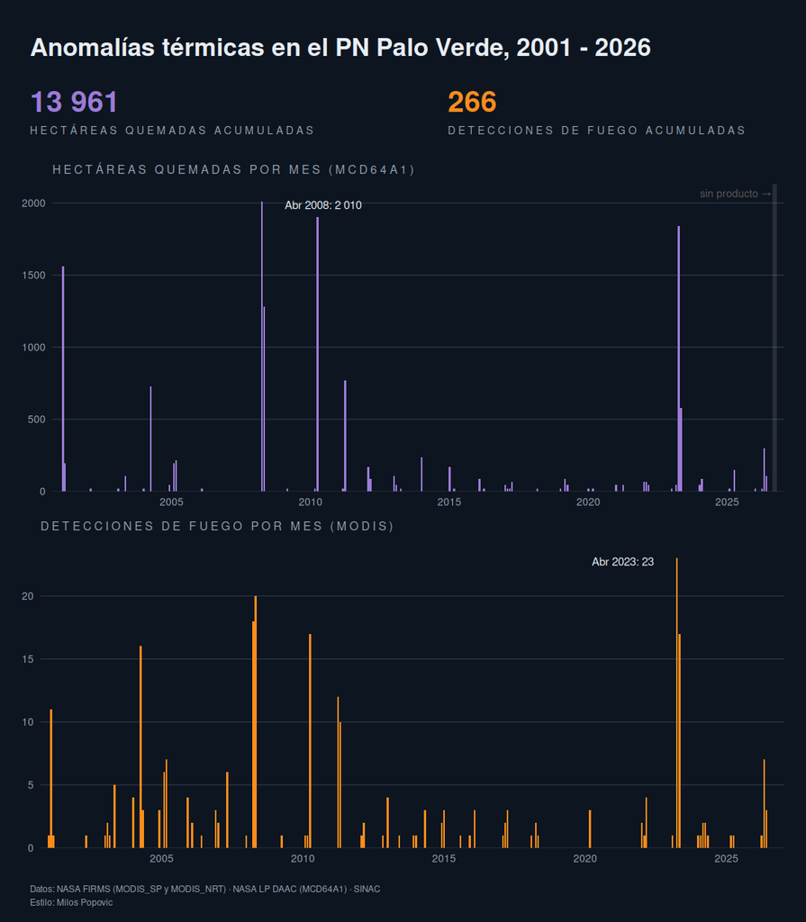

## Mapa interactivo

Use el deslizador temporal para explorar las detecciones a través del tiempo; cada punto muestra sus atributos al pulsarlo, incluida la cobertura de la tierra dominante en su footprint. El botón ⛶ de la esquina superior izquierda abre el mapa en pantalla completa.

Desde el control de capas pueden apagarse las capas de detecciones y del límite del parque —útil para examinar el fondo— y activarse el área quemada (píxeles de MCD64A1, con su fecha de quema en el popup), que el deslizador filtra igual que las detecciones, la cobertura ([ESA WorldCover 2021](https://esa-worldcover.org/)) y las capas nacionales del SINAC: el Registro Nacional de Humedales y la cobertura forestal 2023.

[interactive chart not shown]

## Área quemada (MCD64A1)

Las detecciones de fuego activo indican dónde había fuego al paso del satélite; el producto complementario **MCD64A1** (MODIS, colección 6.1) mapea el **área quemada**: para cada píxel de 500 m (~21,5 ha) registra el día en que la superficie quedó marcada por el fuego, a partir del cambio persistente de reflectancia. Aunque FIRMS lista este producto (`BA_MODIS`) y lo dibuja en su visor, su API no lo entrega como datos, por lo que el pipeline lo descarga del archivo original de la NASA (LP DAAC). El producto se publica con uno o dos meses de rezago: su serie puede terminar antes que la de detecciones.

Las estadísticas de las secciones siguientes presentan ambas magnitudes lado a lado. **Limitación**: la unidad mínima de MCD64A1 es el píxel de 500 m — quemas menores pueden no detectarse y la superficie reportada es la del píxel completo, no la de la cicatriz interna—, por lo que las hectáreas son una estimación gruesa, útil para comparar años y estaciones entre sí.

## Estadísticas

### Serie temporal mensual

Detecciones de fuego activo (arriba) y hectáreas quemadas (abajo), con el eje temporal compartido: acerque con la rueda o arrastre una región para explorar un período; pase el cursor sobre una barra para ver el detalle del mes.

Las dos series son complementarias y **no sumables**: las detecciones cuentan eventos de fuego activo en el momento del sobrevuelo —un mismo incendio genera muchas detecciones a lo largo de días—, mientras que el área quemada mide la superficie que quedó marcada, contada una sola vez. Un mes con muchas detecciones y pocas hectáreas sugiere fuegos recurrentes en poca superficie (o fuegos menores que el píxel de 500 m); el caso inverso, una quema extensa y rápida entre sobrevuelos.

[interactive chart not shown]

### Climatología mensual (estacionalidad)

Promedios por mes calendario de ambas magnitudes. El promedio de hectáreas de los meses más recientes puede estar levemente subestimado por el rezago de publicación de MCD64A1.

[interactive chart not shown]

### Resumen anual

Los años sin detecciones muestran el FRP en blanco (no hubo detecciones que promediar); 0 hectáreas significa que MCD64A1 no marcó píxeles quemados ese año.

| Año | Detecciones | Hectáreas quemadas | FRP promedio (MW) | FRP máximo (MW) |
| --- | --- | --- | --- | --- |
| 2001 | 13 | 1753 | 75 | 321.4 |
| 2002 | 1 | 21 | 12.3 | 12.3 |
| 2003 | 9 | 128 | 25.4 | 41.4 |
| 2004 | 26 | 791 | 62.1 | 244.4 |
| 2005 | 17 | 406 | 34.8 | 91.7 |
| 2006 | 6 | 21 | 33.1 | 62.3 |
| 2007 | 8 | 0 | 29.4 | 69.5 |
| 2008 | 39 | 3292 | 98.6 | 859.8 |
| 2009 | 1 | 21 | 6.4 | 6.4 |
| 2010 | 19 | 1924 | 28 | 50.7 |

[output cut: 16 more lines]

## Cobertura de la tierra

Cada detección MODIS corresponde a un píxel de ~1 km (mayor fuera del nadir), por lo que la cobertura se caracteriza sobre el *footprint* completo de la detección (una elipse con las dimensiones reales del píxel, columnas `scan` × `track`) y no sobre el punto exacto. El gráfico muestra cuántas detecciones tienen cada clase de [ESA WorldCover 2021](https://esa-worldcover.org/) (10 m) como cobertura dominante de su footprint.

**Limitación**: WorldCover describe la cobertura de 2021, mientras que el registro de detecciones abarca 2001–2026; los cambios de cobertura en ese período no están representados.

Cada barra se divide además según la detección caiga o no dentro de un humedal del [Registro Nacional de Humedales](https://geos1pne.sirefor.go.cr/wfs) del SINAC (actualización 2016–2018 del Inventario Nacional de Humedales). El humedal no es un tipo de vegetación que compita con *pastizal* o *bosque*, sino una condición del sitio: las capas del SINAC inventarían rasgos específicos (humedales, bosque) y no cubren todo el territorio, por lo que no pueden sustituir a WorldCover como clasificación exhaustiva, pero sí complementarla.

[interactive chart not shown]

El gráfico gemelo muestra las **hectáreas quemadas** según la clase dominante del píxel MCD64A1. Aquí la clase se asigna al píxel de 500 m completo —no a un footprint elíptico— y aplica la misma limitación de la foto fija de 2021.

[interactive chart not shown]

### Contraste con el Registro Nacional de Humedales

La clase más frecuente, *pastizal*, merece una advertencia: WorldCover es un producto global y clasifica como pastizal buena parte de la marisma del parque.

| Clase WorldCover | Detecciones | En humedal | % en humedal | Fracción del footprint en humedal | Hectáreas quemadas | % del área quemada en humedal |
| --- | --- | --- | --- | --- | --- | --- |
| Pastizal | 186 | 178 | 95.7 | 0.815 | 10561 | 98.8 |
| Bosque | 76 | 50 | 65.8 | 0.157 | 1646 | 46.8 |
| Manglar | 3 | 3 | 100 | 0.644 | 534 | 100 |
| Cultivos | 1 | 1 | 100 | 0.233 | 1176 | 23.6 |
| Cuerpos de agua | 0 | 0 |  |  | 43 | 50 |

Las dos últimas columnas extienden el contraste al área quemada: hectáreas por clase dominante del píxel y qué porcentaje de esas hectáreas cae dentro de un humedal registrado.

**Advertencia sobre la clase de humedal**: el registro asigna una sola clase por polígono, y el polígono *Sector Catalina 1* (4 453 ha, clasificado como *Manglar*) cubre casi todo el sector estuarino del parque, por lo que concentra 148 detecciones. Eso **no** significa que esas quemas ocurran en manglar. Dentro de ese polígono, el manglar cubre apenas el **11,6 %** de la superficie según WorldCover —el 74 % es pastizal— y solo el **4,1 %** según la propia capa de Cobertura Forestal 2023 del SINAC, que sí mapea el manglar como una de sus clases.

Es decir, `clase_hum` describe el tipo de humedal *como sitio* —un complejo estuarino cuyo rasgo distintivo es el manglar— y no la cobertura en cada punto de su extensión. El cruce con el registro es por tanto concluyente para responder si las detecciones ocurren en humedal, pero no para determinar qué tipo de vegetación se quemó; para eso siguen siendo preferibles los productos con detalle espacial fino.

## El episodio del humedal Catalina, mayo de 2026

Casi todo lo que este reporte mide carece de contraparte en tierra: nadie levantó un inventario de las quemas de 2004 para comparar. El episodio de mayo de 2026 es la excepción, y por eso merece una sección propia. El 28 de mayo de 2026 la caída de un rayo encendió el interior del humedal Catalina —el mismo polígono que la sección anterior identifica como el gran sector estuarino del registro—, y una semana después Delfino.cr reportaba, con cifras del Minae-Sinac, que el fuego había afectado **cerca de 4 000 hectáreas** ([nota del 3 de junio de 2026](https://delfino.cr/2026/06/incendio-en-parque-nacional-palo-verde-afecto-cerca-de-4000-hectareas)). El combustible principal fue la *Typha*, una planta invasora que arde incluso sobre el agua. Hay entonces una fecha de ignición, una causa y una superficie oficial: tres cosas con las que auditar los productos satelitales.

**Lo que vio esta plataforma.** MODIS registró **10 detecciones** dentro del parque en 3 días, del 30 de mayo al 1 de junio de 2026 —el fuego apareció en las imágenes 2 días después de la ignición reportada—, con una potencia radiativa acumulada de 300 MW y un máximo de 50,3 MW en un solo píxel.

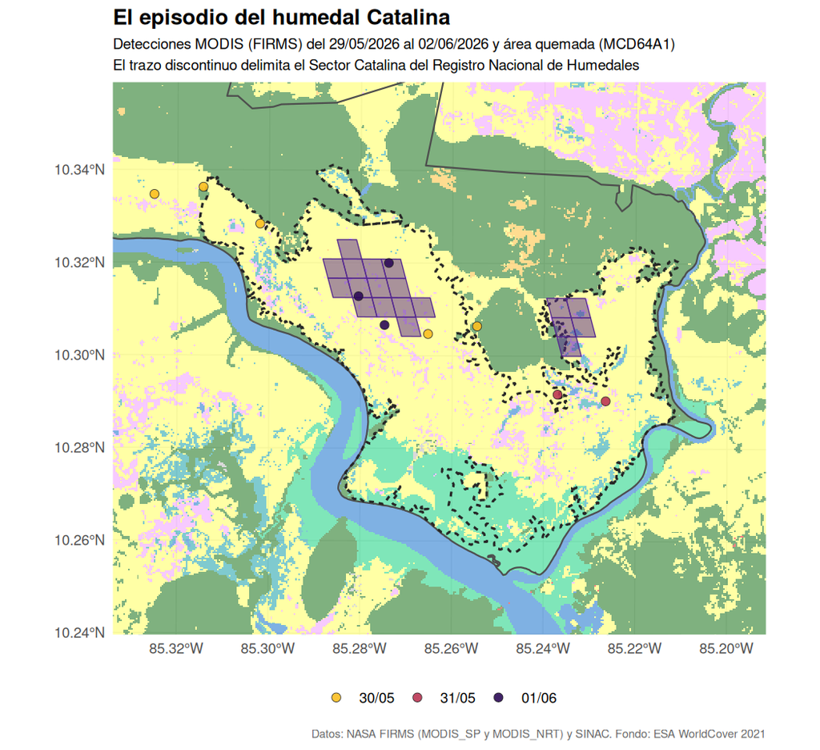

Esas 10 detecciones son el dato más elocuente de esta sección, pero por lo que **no** dicen. Los tres reportes VIIRS registran entre 94 y 163 detecciones del mismo incendio, en los mismos días y sobre el mismo humedal: entre **9 y 16 veces más** que MODIS. La diferencia no está en el fuego sino en el instrumento. El píxel de ~1 km promedia la radiancia sobre una superficie siete veces mayor que el de 375 m, de modo que un frente de llama que ocupa una fracción del píxel eleva su temperatura aparente lo justo para pasar desapercibido. **Un incendio de miles de hectáreas puede reducirse a un puñado de píxeles en MODIS**, y ese es el argumento más concreto a favor de mantener las cuatro plataformas en paralelo en lugar de confiar en la serie más larga.

**Dónde ardió.** El **80,0 %** de las detecciones tiene como polígono dominante el *Sector Catalina*, y el **90,0 %** cae en footprints donde WorldCover ve *pastizal*. Es la confirmación externa del hallazgo de la sección anterior: el “pastizal” que arde en Palo Verde no es potrero sino marisma, y esta vez sabemos por la fuente periodística que lo que ardió fue un typhal sobre agua.

**Lo que el área quemada no vio.** Para mayo y junio de 2026, MCD64A1 marca **406 hectáreas** quemadas dentro del parque, frente a las 4 000 reportadas oficialmente. Con la cicatriz completa —MCD64A1 ya publicó todos los meses del evento— la brecha es de **9,8 veces**; el reporte de Suomi-NPP, con VNP64A1, la sitúa en 5,7 veces.

La explicación está en cómo funciona el producto. MCD64A1 declara quemado un píxel de 500 m cuando detecta un **cambio persistente de reflectancia**, y una quema de *Typha* sobre lámina de agua no lo produce: la vegetación emergente desaparece, el agua vuelve a dominar la señal y a las pocas semanas la superficie se parece a lo que era antes. A eso se suma que el píxel de 500 m no resuelve las cicatrices delgadas e interrumpidas que deja un fuego que avanza entre canales. No es un defecto de este episodio sino el comportamiento esperable del algoritmo en humedales, y advierte contra leer las hectáreas de la tabla anual como una medida de la superficie realmente afectada: **sirven para comparar años entre sí, no para responder cuántas hectáreas se quemaron.**

## ¿El fuego bordea el bosque o lo rodea?

En el mapa interactivo las detecciones parecen dibujar el contorno del bloque forestal. Conviene distinguir dos situaciones que se ven igual sobre el mapa: que el fuego busque la línea de contacto con el bosque —que lo *bordee*— o que simplemente ocurra en las áreas abiertas que lo circundan —que lo *rodee*—. En un parque cuyo bosque forma un bloque compacto, cualquier concentración en terreno abierto traza su silueta sin que exista preferencia alguna por el borde.

El primer indicio está en la composición: el parque es **54,0 %** bosque y **36,0 %** pastizal según WorldCover, pero solo el **28,6 %** de las detecciones tiene bosque como clase dominante de su footprint, frente al **69,9 %** con pastizal. El área quemada apunta en la misma dirección y con más fuerza: apenas el **11,8 %** de las hectáreas quemadas cae en píxeles dominados por bosque, contra el **75,7 %** en pastizal. El fuego está sobrerrepresentado en la vegetación herbácea —que, como muestra la sección anterior, corresponde en su gran mayoría a la marisma del parque— y subrepresentado en el bosque.

Para separar el “efecto de borde” de la ilusión geométrica se compara cada detección contra un modelo nulo: **3000** puntos aleatorios dentro del parque, es decir, la hipótesis de que el fuego se distribuye como el paisaje disponible. De cada punto se calcula la fracción de bosque en **500 m** a la redonda, que tiende a 1 en el interior del bosque y a 0 en terreno abierto; los valores intermedios son justamente los bordes.

| Situación paisajística | % de las detecciones | % del área quemada | % esperado por azar |
| --- | --- | --- | --- |
| Abierto (&lt;20 % de bosque alrededor) | 58.64661654135338 | 74.42563603424225 | 33.83333333333334 |
| Borde (20–80 %) | 25.56390977443609 | 22.20528127586585 | 28.2 |
| Interior de bosque (&gt;80 %) | 15.78947368421053 | 3.369082689891907 | 37.96666666666667 |

La tabla contrasta tres repartos: el de las detecciones, el del área quemada —medida sobre los centroides de los **653** píxeles de MCD64A1 y ponderada por su superficie— y el esperado por azar. La prueba estadística se aplica solo a las detecciones; la columna del área quemada se lee contra la misma referencia aleatoria.

Si los incendios prefirieran el borde, la fila central estaría sobrerrepresentada. No lo está: **25,6 %** de las detecciones contra **28,2 %** esperado por azar, una diferencia no significativa (prueba de proporciones, *p* = 0,40). Lo que sí está fuertemente desplazado son los extremos: las detecciones ocurren en terreno abierto casi al doble de lo esperado (**58,6 %** contra **33,8 %**) y en interior de bosque a menos de la mitad (**15,8 %** contra **38,0 %**). La mediana de bosque circundante es **0,04** en las detecciones y **0,57** en los puntos aleatorios.

### El área quemada agudiza el patrón

El segundo instrumento no solo confirma el resultado: lo vuelve más nítido. El **74,4 %** de las hectáreas quemadas está en terreno abierto —frente al 58,6 % de las detecciones y al 33,8 % esperado por azar— y en el interior del bosque el fuego prácticamente desaparece: **3,4 %** de las hectáreas contra un 38,0 % esperado, es decir, cerca de 11 veces menos. La mediana de bosque circundante baja de 0,04 en las detecciones a **0,013** en los píxeles quemados.

La diferencia entre ambos instrumentos es en sí misma informativa, y apunta al tamaño del píxel. Una detección es el centro de un footprint cuya mediana supera 1 km²: cuando un fuego arde en la marisma contigua al bosque, ese footprint invade el bosque y la detección puede quedar clasificada como interior forestal. MCD64A1 no tiene ese desborde —sitúa la cicatriz en un píxel de 500 m— y al medir con él, el interior de bosque se reduce a una fracción mínima. Buena parte del 15,8 % de detecciones en interior de bosque es, entonces, un artefacto de resolución más que fuego de dosel.

La conclusión es que **el fuego no bordea el bosque: lo rodea**. Ocurre en las áreas abiertas y, como el bosque es un bloque continuo, lo abierto es justamente lo que lo circunda. La distinción no es de matiz: bordearlo supondría que el fuego busca la línea de contacto, y eso es lo que los datos descartan, ahora con dos productos independientes que coinciden.

**Limitación**: el modelo nulo supone que cualquier punto del parque tiene la misma probabilidad de arder, lo que ignora factores como la accesibilidad o la cercanía a caminos y linderos. Descarta la explicación geométrica del patrón, pero no identifica la causa de las igniciones.

## Fuentes de datos

- **NASA FIRMS** — Fire Information for Resource Management System, producto MODIS_SP (MODIS Collection 6.1, procesamiento estándar). https://firms.modaps.eosdis.nasa.gov/. Cita sugerida: NASA FIRMS, *MODIS Collection 6.1 Active Fire Detections*, DOI: 10.5067/FIRMS/MODIS/MCD14ML.
- **NASA LP DAAC** — producto de área quemada MCD64A1 v6.1 (MODIS Terra+Aqua, mensual, 500 m), descubierto vía el API CMR de Earthdata. Giglio, L., et al. (2021). *MCD64A1 MODIS/Terra+Aqua Burned Area Monthly L3 Global 500m SIN Grid V061*, DOI: 10.5067/MODIS/MCD64A1.061.
- **SINAC** — Sistema Nacional de Áreas de Conservación de Costa Rica. Capas de áreas silvestres protegidas (capa oficial 1:5000, publicada en 2019), Registro Nacional de Humedales (actualización 2016–2018) y Cobertura Forestal 2023, descargadas de su servicio WFS. https://geos1pne.sirefor.go.cr/wfs.
- **ESA WorldCover** — mapa global de cobertura de la tierra 2021 a 10 m, v200. https://esa-worldcover.org/. Zanaga, D., et al. (2022). *ESA WorldCover 10 m 2021 v200*, DOI: 10.5281/zenodo.7254221.

El código de este análisis está disponible en https://github.com/incendios-forestales/anomalias-termicas-paloverde.